# Tvyal Newsletter

Aghasi Tavadyan

2023-12-18

*English summary below.*

Հարգելի գործընկեր,

Հուսով եմ լավ եք: Ներկայացնում եմ անցած շաբաթվա վերլուծությունները և աշխատանքները.

1. Գյուղատնտեսությունից արդյունաբերություն անցումը
2. Սխալների ուղղում
3. ԶԼՄ հաղորդագրություններ
4. English summary
5. Նվեր Ամանորի նախօրեին / A little gift before Christmas

## 1. Գյուղատնտեսությունից արդյունաբերություն անցումը

### Կամ գյուղատնտեսությունը կոլապսի է ենթարվել

Ընդհանուր առմամբ այս 10 տարում ՀՆԱ-ն ավելի քան կրկնապատկվել է`2013-ին կազմելով 6.38 տրիլիոն դրամ, իսկ 2023-ին ակնկալվում է որ ՀՆԱ-ն լինելու է ավելի քան 13 տրլն դրամ: 10 տարի առաջ 2013 թվականին Հայաստանի ՀՆԱ-ի 19.5 տոկոսը ապահովում էր գյուղատնտեսությունը, որը կազմում էր 1.24 տրիլիոն դրամ, արդյունաբերությունը գտնվում էր երկրորդ տեղում` կազմելով ՀՆԱ-ի 14.3 տոկոսը, կամ 920 մլրդ դրամ:

2023 թվականին պատկերը հակառակն է արդյունաբերությունը արդեն գտնվում է առաջին տեղը` ապահովելով ՀՆԱ-ի 17.3 տոկոսը, իսկ գյուղատնտեսությունը այս 10 տարվա մեջ գրեթե 20 տոկոս բաժնեմասից իջել է 10.2 տոկոսի:

**Գծապատկեր 1.** ՀՆԱ մեջ ապրանքների և ծառայությունների թողարկումն փոփոխությունը

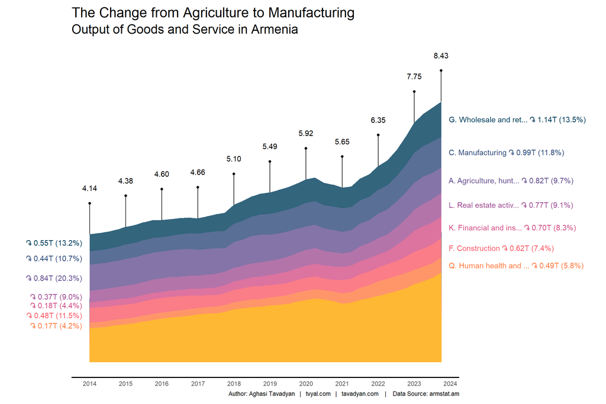

Դիտարկենք թե ապրանքների և ծառայությունների թողարկման որ ճյուղերն են ունեցել ամենազգալի աճը այս 10 տարիների ընթացքում:

Ֆինանսական և ապահովագրական գործունեությունը աճել է ավելի քան 3.6 անգամ

- նշում. Այս հետազոտության մեջ 2023 թվականի տվյալները 2023 թվականի 1-ին, 2-րդ, 3-րդ, ինչպես նաև 2022 թվականի 4-րդ եռամսյակի կումուլատիվ գումարն են, որը ներկայացնում է տարեկան արժեքը:

**Գծապատկեր 2.** ՀՆԱ կառուցվածքի 2013-ից մինչև 2023 աճի համեմատություն

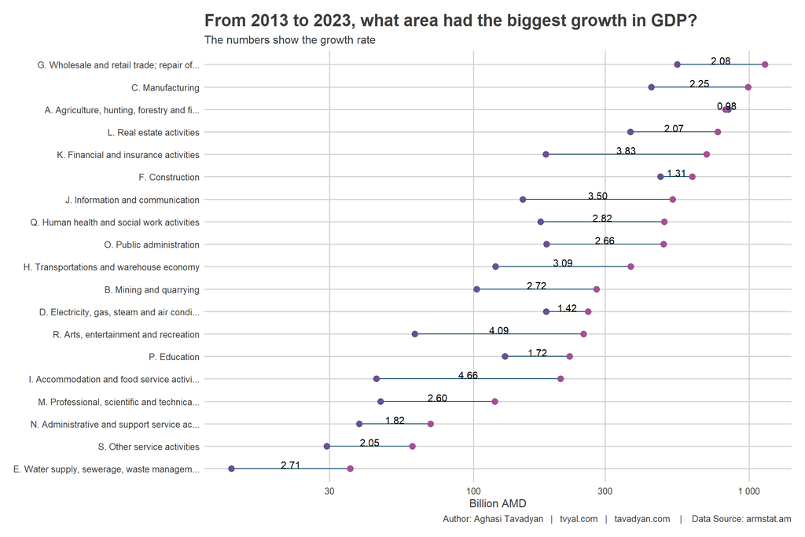

## 2. Սխալների ուղղում

Նախորդ նյութի մեջ առկա է կանխատեսման սխալ, որը պատճառը այն է որ [2023թ հուլիսից վիճակագրական կոմիտեում տեղադրված էլեկտրաէներգիայի արտադրության ծավալներում](https://www.armstat.am/file/article/sv_07_23a_121.pdf) ներառված են նաև էլեկտրաէներգիայի փոխհոսքերի մասով ինքնավար արտադրողների կողմից արտադրված էլեկտրաէներգիայի ծավալները: Տվյալների բազան ստացել է այս հաշվետվությունները համացանցից ավտոմատացված կերպով ներբեռնելով և տվյալների բազայի ավտոմատացված հաշվարկմամբ, որտեղ ամսվա տվյալը ստացվել է տվյալ ամսից հանելով նախորդ ամսվա կումուլատիվ գումարը:

Այս հանգամանքով անցած շաբաթ Ձեզ ուղարկած նյուզլեթերի մեջ 2023 թվականի հունի արևային էլեկտրաէներգիայի արտադրության տվյալը իր մեջ ներառում է այդ ամսվա կոմերցիոն արտադրության ծավալները, ինչպես նաև 2023 թվականի սկզբից մինչև հունիսը ներառյալ ինքնավար արտադրողների կողմից արտադրված էլեկտրաէներգիայի ծավալները: Դա է պատճառը որ տվյալների մեջ առկա է հանկարծակի և չկրկնվող աճ 2023թ. հունիսին, որը ենթադրաբար կազմում էր այդ ամսվա արտադրության մոտ 30 տոկոսը: Սա սխալ է:

Նախորդ վերլուծության մեջ բոլոր գծապատկերները, հաշվարկները, կանխատեսումները և տեքստը արդեն ուղղված են: [Սեղմեք այս հղումը ճշգրտված տարբերակին անցնելու համար](https://www.tvyal.com/newsletter/2023_12_11): [Հին տարբերակը չի ջնջվի և լինելու է այս հղման տակ](https://www.tvyal.com/newsletter/2023_12_11_old):

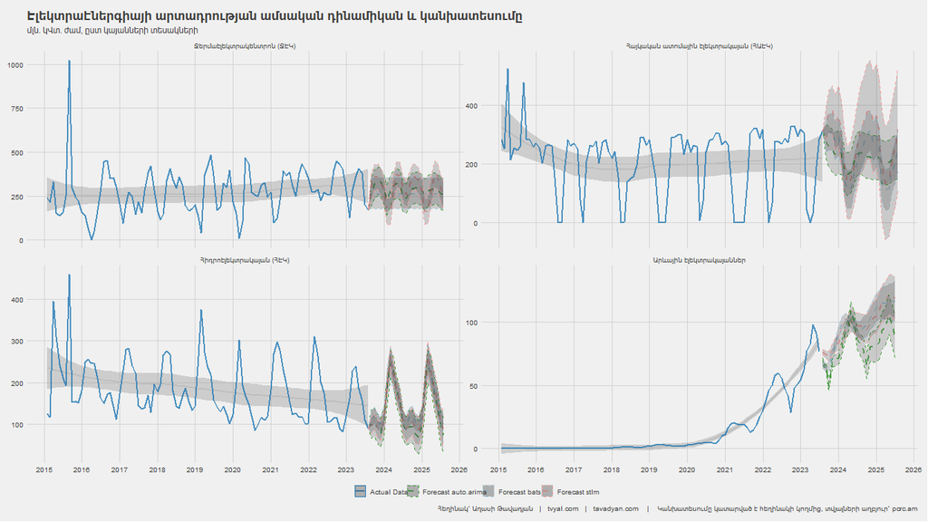

## 3. ԶԼՄ հաղորդագրություններ

[Panorama.am](https://www.youtube.com/watch?v=FV0NqHOHfY4) լրատվամիջոցին տվել եմ հարցազրույց:

Այս վիդիոնյութը, ըստ իս, դեռևս իմ ամենաանմիջական զրույցներից է: Խորհուրդ եմ տալիս դիտել այն: Պետք է հասկանալ, թե 2023 թ.-ին ինչու չունեցանք 2022 թ-ի չափ բարձր տնտեսական աճ:

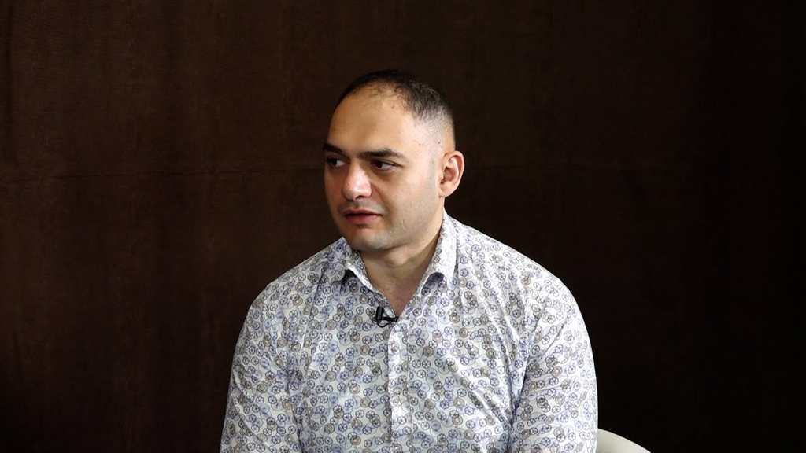

## 4. English Summary

**The transition from agriculture to industry in Armenia**

## 5. Նվեր Ամանորի նախօրեին / A little gift beforе Christmas

Ձեզ եմ ընծայում իմ կողմից կոդով ստեղսված նկարը:

Անվանումը` **Թռչուններ և խխունջներ**

Title: **Birds & Snails**

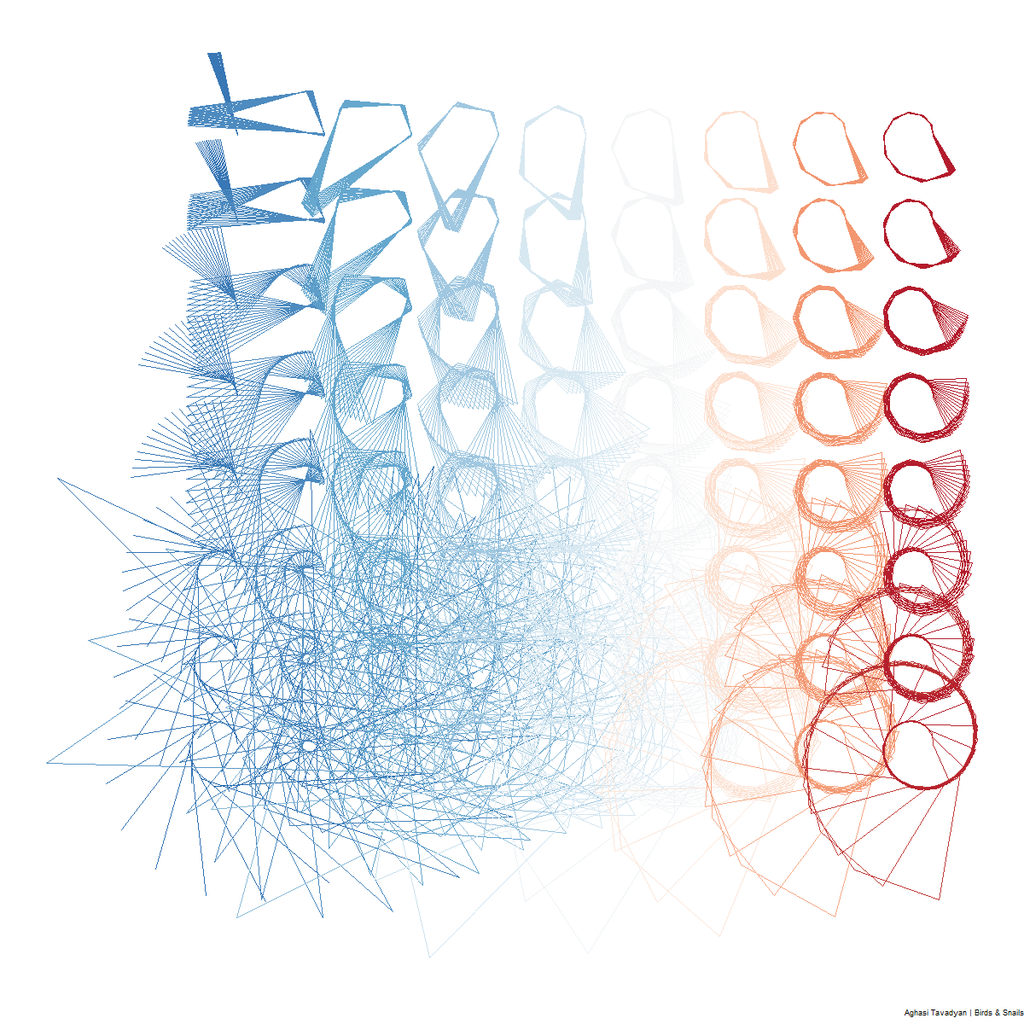

Սպասեք ավելի շատ նվարներ հաջորդ նյուզլեթերին, որը լինելու է մեր կողմից պատրաստած այս տարվա վերջին հաղորդագրությունը:

## Այս վերլուծությունը առկա է նաև [մեր կայքէջում](https://www.tvyal.com/newsletter/2023_12_18), այս վերլուծության կոդը և տվյալները դրված են նաև [Github-ում](https://github.com/tavad/tvyal_newsletter)։

Եթե հնարավոր է, խնդրում եմ այս նյութը ուղարկել նաև այն մարդկանց, ում այն կարծում եք կարող է հետաքրքրել:

Սպասեք հաջորդ հաղորդագրությանը մի շաբաթվա ընթացքում:

Հարգանքներով,  
Աղասի Թավադյան  
18.12.2023  
[tvyal.com](https://www.tvyal.com/)  
[tavadyan.com](https://www.tavadyan.com/)

[Was this email forwarded to you? Subscribe here.](https://www.tvyal.com/subscribe)

[Բաժանորդագրվեք](https://www.tvyal.com/subscribe)

**Ուշադրություն. Ձեր էլ.փոստը մեյլիսթի մեջ է, որի միջոցով ես կիսվում եմ շաբաթական նյութեր, որոնք հիմնականում ներկայացնում են Հայաստանի տնտեսությանը: Նյութերը ներառում են գծապատկերներ, [տվյալների բազաներ](https://github.com/tavad/tvyal_newsletter), տեսանյութեր, հոդվածներ, [առցանց վահանակներ](https://www.tvyal.com/projects), տնտեսական գործիքներ, կանխատեսումներ և հաշվետվություններ: Եթե ցանկանում եք չեղարկել բաժանորդագրությունը, խնդրում եմ տեղեկացրեք ինձ, և ես կհեռացնեմ ձեր էլ. փոստը ցուցակից: Գրեք նաև եթե ունեք մենկնաբանություններ:**

**Important! Your email is part of the mailing list where I share weekly materials primarily focused on the Armenian economy. These materials encompass charts, [databases](https://github.com/tavad/tvyal_newsletter), videos, articles, [online dashboards](https://www.tvyal.com/projects), economic tools, forecasts, and reports. If you wish to unsubscribe, please let me know, and I will remove your email from the list. Please share your comments as well․**